# Programming with Python

## Data visualization with Matplotlib

#### Asst. Prof Roshan Tandukar

### Matplotlib

It is a low level graph plotting library in python that serves as a visualization utility.

It was created by John D. Hunter.

It is open source and we can use it freely.

It is mostly written in python, a few segments are written in C, Objective-C and Javascript for Platform compatibility.

### Introduction to pyplot

The matplotlib.pyplot is a collection of functions that make matplotlib work like MATLAB.

Each pyplot function makes some change to a figure: e.g., creates a figure, creates a plotting area in a figure, plots some lines in a plotting area, decorates the plot with labels, etc.

In matplotlib.pyplot various states are preserved across function calls, so that it keeps track of things like the current figure and plotting area, and the plotting functions are directed to the current Axes (please note that we use uppercase Axes to refer to the Axes concept, which is a central part of a figure and not only the plural of axis).

### Plotting

- Standard line plotting
- Other plotting + text annotation
- 3D plotting  
  -- 3D axes + 3D line/surface plotting
- Other plotting  
  -- Contours + image visualization

### Import convention

- from matplotlib import pyplot as plt
- import matplotlib.pyplot as plt

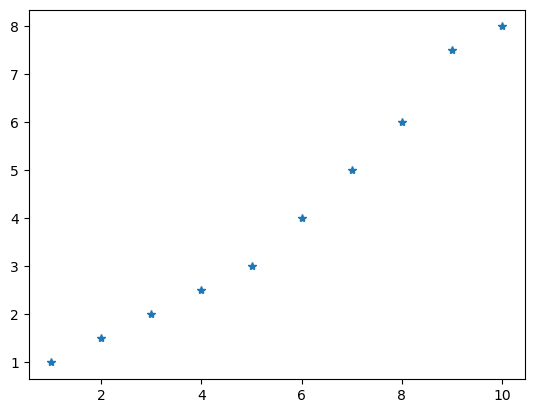

```python
import numpy as np
import matplotlib.pyplot as plt
x=np.array([1,2,3,4,5,6,7,8,9,10])
y=np.array([1,1.5,2,2.5,3,4,5,6,7.5,8])
plt.plot(x,y,'*')
plt.show()
```

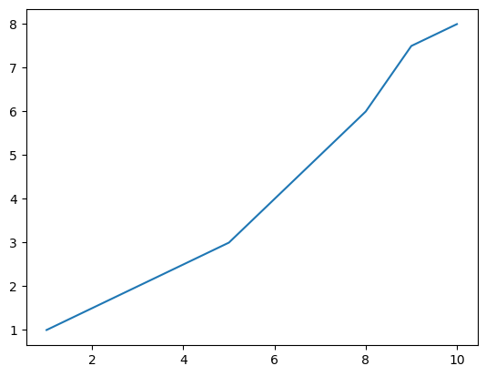

```python
plt.plot(x,y,'-')
plt.show()
```

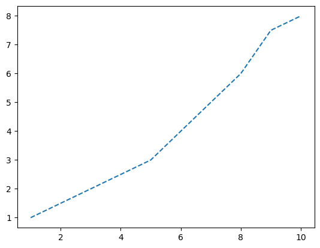

```python
plt.plot(x,y,'--')
plt.show()
```

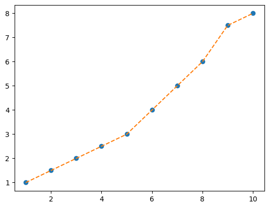

```python
plt.plot(x,y,'o',x,y,'--')
plt.show()
```

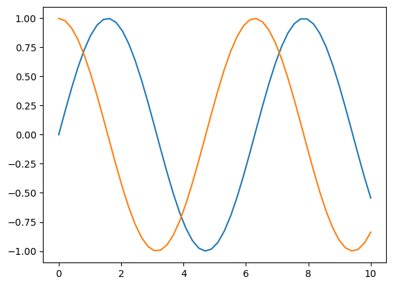

```python
x=np.linspace(0,10)
sx,cx=np.sin(x),np.cos(x)
plt.plot(x,sx)
plt.plot(x,cx)
plt.show()
```

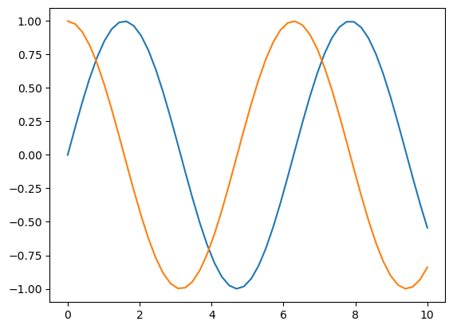

```python
x=np.linspace(0,10)
sx,cx=np.sin(x),np.cos(x)
plt.plot(x,sx,x, cx)
plt.show()
```

### Title and labels in a graph

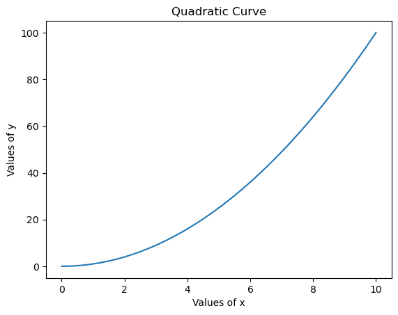

```python
import numpy as np
import matplotlib.pyplot as plt
x = np. linspace (0, 10, 1000) #parameters(start,stop, numberOfSamplesTogenerate)
y = np. power(x, 2)
plt.plot(x, y)
plt.title('Quadratic Curve')
plt.xlabel('Values of x')
plt.ylabel('Values of y')
plt.show()
```

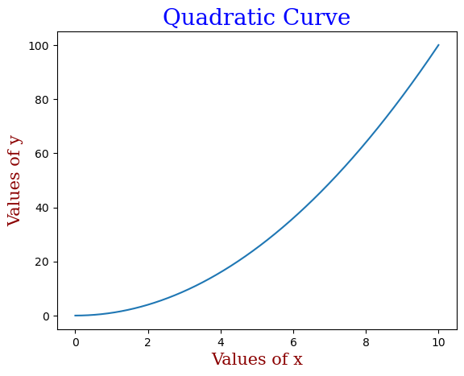

```python
import numpy as np
import matplotlib.pyplot as plt
x = np. linspace (0, 10, 1000)
y = np. power(x, 2)

font1 = {'family':'serif','color':'blue','size':20}
font2 = {'family':'serif','color':'darkred','size':15}

plt.plot(x, y)
plt.title('Quadratic Curve', fontdict = font1)
plt.xlabel('Values of x', fontdict = font2)
plt.ylabel('Values of y', fontdict = font2)
plt.show()
```

### Grid

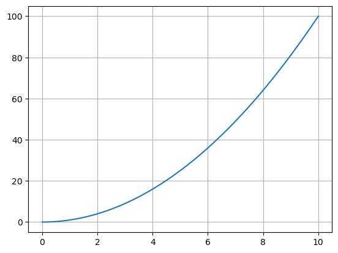

```python
import numpy as np
import matplotlib.pyplot as plt
x = np.linspace (0, 10, 1000)
y = np.power(x, 2)
plt.plot (x, y)
plt.grid()
plt.show()
```

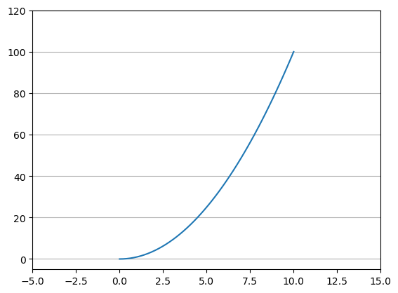

```python
import numpy as np
import matplotlib.pyplot as plt
x = np.linspace (0, 10)
y = np.power(x, 2)
plt.plot (x, y)
plt.xlim(-5,15)
plt.ylim(-5,120)
plt.grid(axis='y')
plt.show()
```

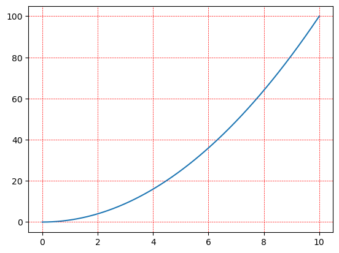

```python
import numpy as np
import matplotlib.pyplot as plt
x = np.linspace (0, 10, 1000)
y = np.power(x, 2)
plt.plot (x, y)
plt.grid(color='red',linestyle='--',linewidth=0.5)
plt.show()
```

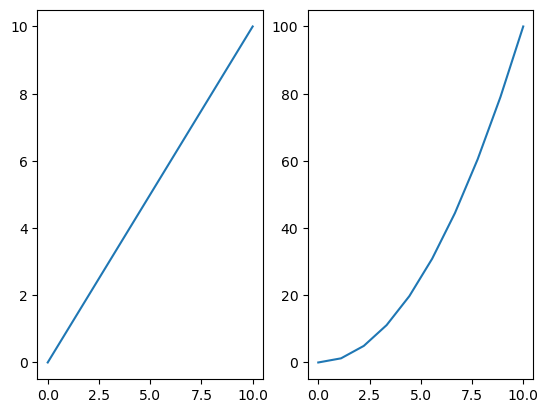

```python
import numpy as np
import matplotlib.pyplot as plt
x = np.linspace (0, 10, 10)
y = np.power(x, 2)
plt.subplot(1,2,1) #1 row, 2 columns, and this plot is the first plot.
plt.plot(x,x)
plt.subplot(1,2,2) #1 row, 2 columns, and this plot is the second plot.
plt.plot(x,y)
plt.show()
```

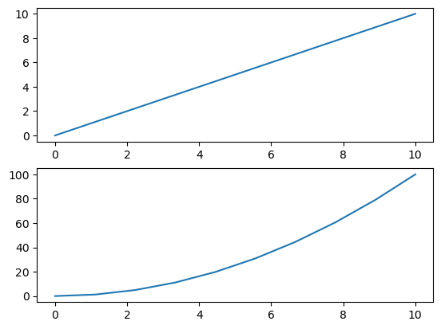

```python
import numpy as np
import matplotlib.pyplot as plt
x = np.linspace (0, 10, 10)
y = np.power(x, 2)
plt.subplot(2,1,1) #2 rows, 1 column, and this plot is the first plot.
plt.plot(x,x)
plt.subplot(2,1,2) #2 rows, 1 column, and this plot is the second plot.
plt.plot(x,y)
plt.show()
```

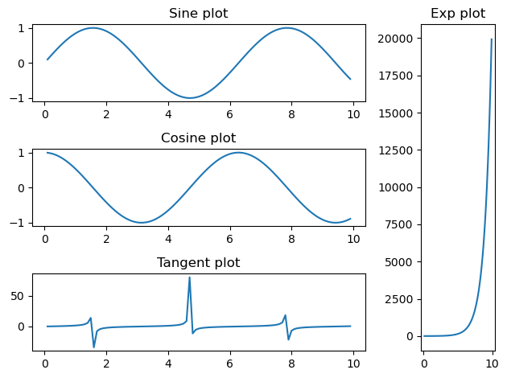

```python
import numpy as np
import matplotlib.pyplot as plt
x = np.arange(0.1, 10, 0.1)
y1 = np.sin(x)
y2 = np.cos(x)
y3 = np.tan(x)
y4 = np.exp(x)

fig = plt.figure()
ax1 = plt.subplot2grid((3,4),(0,0),colspan = 3)
ax2 = plt.subplot2grid((3,4),(1,0),colspan = 3)
ax3 = plt.subplot2grid((3,4),(2,0),colspan = 3)
ax4 = plt.subplot2grid((3,4),(0,3),rowspan = 3)

ax1.plot(x, y1)
ax2.plot(x, y2)
ax3.plot(x, y3)
ax4.plot(x, y4)

ax1.set_title("Sine plot")
ax2.set_title("Cosine plot")
ax3.set_title("Tangent plot")
ax4.set_title("Exp plot")

plt.tight_layout()
plt.show()
```

### Scatter plot

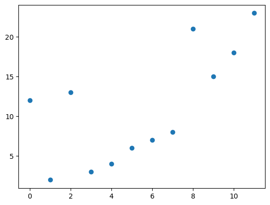

```python
import matplotlib.pyplot as plt
import numpy as np

x = np.arange(12)
y = np.array([12,2,13,3,4,6,7,8,21,15,18,23])
plt.scatter(x, y)
plt.show()
```

### Compare plots

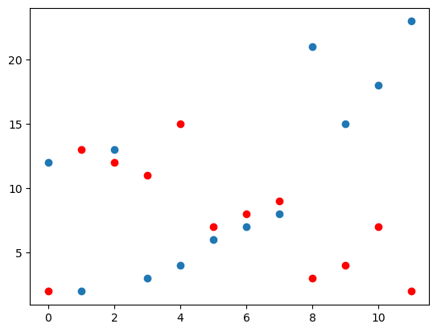

```python
import matplotlib.pyplot as plt
import numpy as np

x = np.arange(12)
y = np.array([12,2,13,3,4,6,7,8,21,15,18,23])
z = np.array([2,13,12,11,15,7,8,9,3,4,7,2])
plt.scatter(x, y)
plt.scatter(x, z,color='red')
plt.show()
```

### Matplotlib Bars

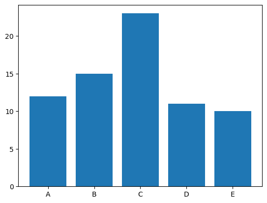

```python
import matplotlib.pyplot as plt
import numpy as np

x = np.array(['A','B','C','D','E'])
y = np.array([12,15,23,11,10])

plt.bar(x,y)
plt.show()
```

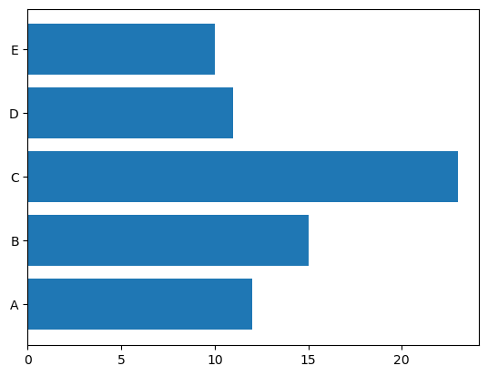

```python
import matplotlib.pyplot as plt
import numpy as np

x = np.array(['A','B','C','D','E'])
y = np.array([12,15,23,11,10])

plt.barh(x,y)
plt.show()
```

### Matplotlib Histogram

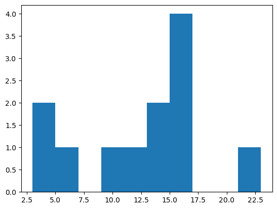

```python
import matplotlib.pyplot as plt
import numpy as np

#x = np.random.normal(170, 10, 250)
x=np.array([12,16,6,14,10,16,13,4,15,23,16,3])
plt.hist(x)
plt.show()
```

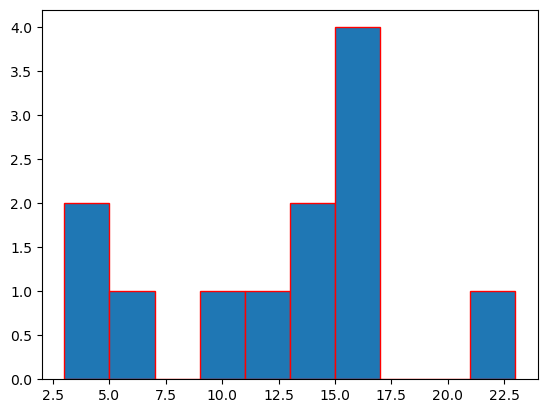

```python
import matplotlib.pyplot as plt
import numpy as np

#x = np.random.normal(170, 10, 250)
x=np.array([12,16,6,14,10,16,13,4,15,23,16,3])
plt.hist(x, histtype='bar',ec='red')
plt.show()
```

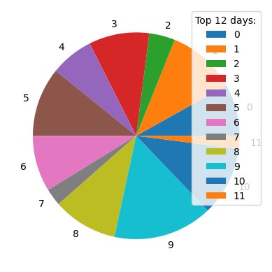

```python
count=np.arange(12)
plt.pie(x, labels=count)
plt.legend(title = "Top 12 days:",loc='upper right')
plt.show()
```

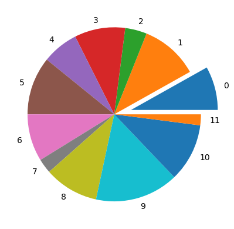

```python
count=np.arange(12)
val=[0.2,0,0,0,0,0,0,0,0,0,0,0]
plt.pie(x, labels=count,explode=val)
plt.show()
```

### Box Plot

A Box plot is a way to visualize the distribution of the data by using a box and some vertical lines.

It is also known as the whisker plot.

The data can be distributed between five key ranges, which are as follows:

Minimum: Q1-1.5IQR  
1st quartile (Q1): 25th percentile  
Median:50th percentile  
3rd quartile(Q3):75th percentile  
Maximum: Q3+1.5IQR

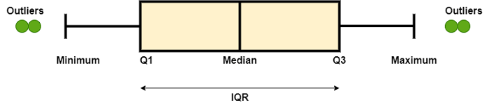

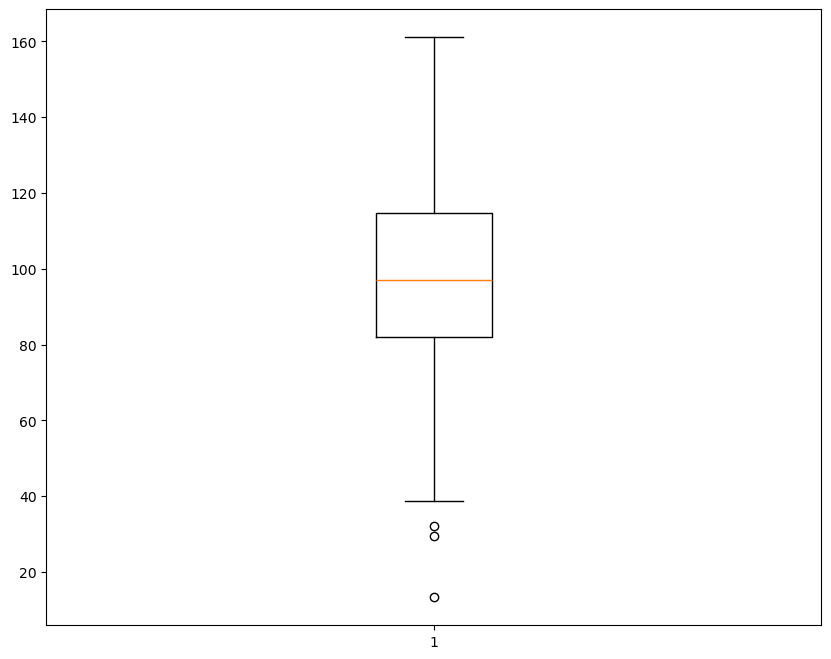

```python
import matplotlib.pyplot as plt
import numpy as np
np.random.seed(15)
dataSet = np.random.normal(100, 25, 200)
figure = plt.figure(figsize =(10, 8))
plt.boxplot(dataSet)
plt.show()
```

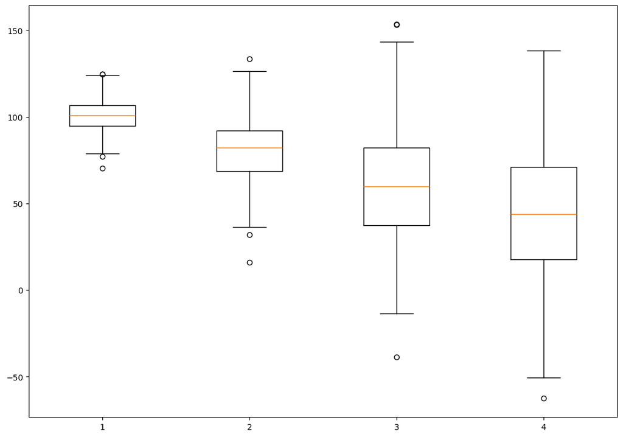

```python
import matplotlib.pyplot as plt
import numpy as np

np.random.seed(10)

dataSet1 = np.random.normal(100, 10, 220)
dataSet2 = np.random.normal(80, 20, 200)
dataSet3 = np.random.normal(60, 35, 220)
dataSet4 = np.random.normal(50, 40, 200)
dataSet = [dataSet1, dataSet2, dataSet3, dataSet4]

figure = plt.figure(figsize =(10, 7))
ax = figure.add_axes([0, 0, 1, 1])
bp = ax.boxplot(dataSet)
plt.show()
```

### 3D Plot

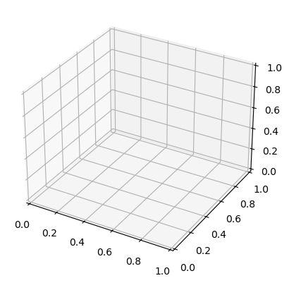

```python
import matplotlib.pyplot as plt

fig = plt.figure()
ax = plt.axes(projection='3d')
plt.show()
```

```
[Text(0.5, 0.92, 'parametric curve')]
```

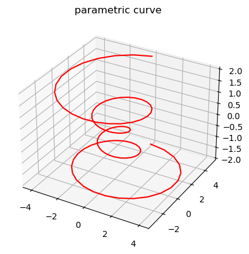

```python
import numpy as np
theta = np.linspace(-4*np.pi, 4*np.pi, 100)
z = np.linspace(-2, 2, 100)
r = z**2 + 1
x = r * np.sin(theta)
y = r * np.cos(theta)
ax = plt.axes(projection='3d')
ax.plot(x, y, z, 'r')
ax.set(title='parametric curve')
```

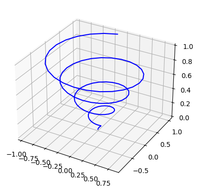

```python
import matplotlib.pyplot as plt
import numpy as np

# Create 3D figure environment
fig = plt.figure()
ax = plt.axes(projection='3d')

# Generate sample data
z = np.linspace(0, 1, 100)
x = z * np.sin(25 * z)
y = z * np.cos(25 * z)

# Plot a 3D line
ax.plot3D(x, y, z, 'blue')
plt.show()
```

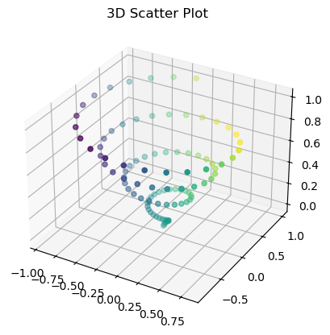

```python
fig = plt.figure()
ax = plt.axes(projection='3d')

z = np.linspace(0, 1, 100)
x = z * np.sin(25 * z)
y = z * np.cos(25 * z)
c = x + y  # Color array based on x and y

ax.scatter(x, y, z, c=c)
ax.set_title('3D Scatter Plot')
plt.show()
```

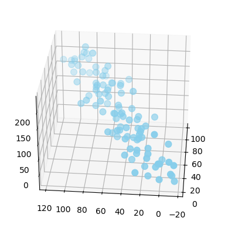

```python
# libraries
from mpl_toolkits.mplot3d import Axes3D
import matplotlib.pyplot as plt
import numpy as np
import pandas as pd

df=pd.DataFrame({'X': range(1,101), 'Y': np.random.randn(100)*15+range(1,101), 'Z': (np.random.randn(100)*15+range(1,101))*2 })

fig = plt.figure()
ax = fig.add_subplot(111, projection='3d')
ax.scatter(df['X'], df['Y'], df['Z'], c='skyblue', s=60)
ax.view_init(30, 185)
plt.show()
```

```python
df
```

|  | X | Y | Z |
| --- | --- | --- | --- |
| 0 | 1 | 26.064671 | 7.339432 |
| 1 | 2 | 1.902949 | 37.186003 |
| 2 | 3 | 0.593149 | -16.514808 |
| 3 | 4 | -11.249172 | 0.555505 |
| 4 | 5 | -14.306833 | 27.570576 |
| ... | ... | ... | ... |
| 95 | 96 | 87.933847 | 182.767673 |
| 96 | 97 | 104.073859 | 171.598398 |
| 97 | 98 | 116.873876 | 173.245445 |
| 98 | 99 | 90.752982 | 194.580862 |
| 99 | 100 | 108.333781 | 167.556880 |

100 rows × 3 columns

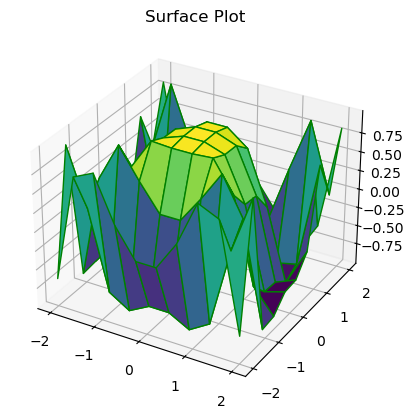

```python
x = np.outer(np.linspace(-2, 2, 10), np.ones(10))
y = x.copy().T
z = np.cos(x**2 + y**3)

fig = plt.figure()
ax = plt.axes(projection='3d')
ax.plot_surface(x, y, z, cmap='viridis', edgecolor='green')
ax.set_title('Surface Plot')
plt.show()
```

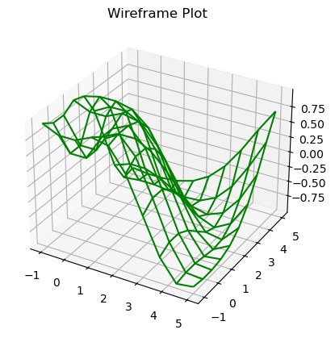

```python
def f(x, y):
    return np.sin(np.sqrt(x**2 + y**2))

x = np.linspace(-1, 5, 10)
y = np.linspace(-1, 5, 10)
X, Y = np.meshgrid(x, y)
Z = f(X, Y)

fig = plt.figure()
ax = plt.axes(projection='3d')
ax.plot_wireframe(X, Y, Z, color='green')
ax.set_title('Wireframe Plot')
plt.show()
```

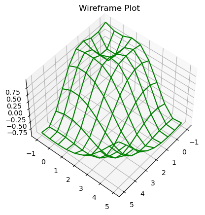

```python
def f(x, y):
    return np.sin(np.sqrt(x**2 + y**2))

x = np.linspace(-1, 5, 10)
y = np.linspace(-1, 5, 10)
X, Y = np.meshgrid(x, y)
Z = f(X, Y)

fig = plt.figure()
ax = plt.axes(projection='3d')
ax.plot_wireframe(X, Y, Z, color='green')
ax.set_title('Wireframe Plot')

ax.view_init(elev=50, azim=40)
plt.show()
```

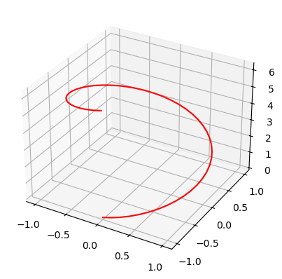

```python
theta = np.linspace(0, 2*np.pi)
x = np.cos(theta - np.pi/2)
y = np.sin(theta - np.pi/2)
z = theta
ax = plt.axes(projection='3d')
ax.plot(x, y, z, 'r')
plt.show()
```

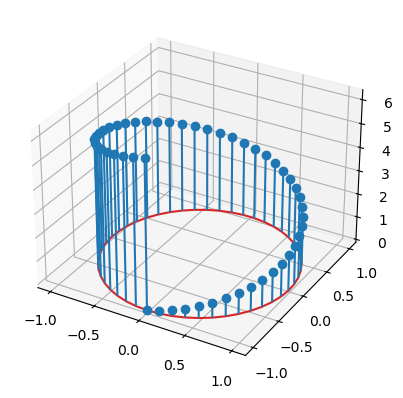

```python
import matplotlib.pyplot as plt
import numpy as np

theta = np.linspace(0, 2*np.pi)
x = np.cos(theta - np.pi/2)
y = np.sin(theta - np.pi/2)
z = theta
ax = plt.axes(projection='3d')
ax.stem(x, y, z)
plt.show()
```

# Any questions???

```python
x=np.linspace(1,5,11
             )
x
```

```
array([1. , 1.4, 1.8, 2.2, 2.6, 3. , 3.4, 3.8, 4.2, 4.6, 5. ])
```